# evans_inclass_lab_2

Nathaniel Evans

October 4, 2018

```r
library(moderndive)
library(tidyverse)
library(skimr)
library(readr)
```

```r
crimenames <- c("county", "region_name", "region_code",
               "criminals", "public_houses", "school_attendance",
               "worship_attendance")

crime <- read_table(here::here("data", "beerhall.dat"),
                    col_names = crimenames)
head(crime)
```

```
## # A tibble: 6 x 7
##   county region_name region_code criminals public_houses school_attendan~
##   <chr>  <chr>             <int>     <int>         <int>            <int>
## 1 Middl~ South East~           1       200           541              560
## 2 Surrey South East~           1       160           504              630
## 3 Kent   South East~           1       160           552              790
## 4 Sussex South East~           1       147           295              820
## 5 Hants  South East~           1       178           409              990
## 6 Berks  South East~           1       205           568              930
## # ... with 1 more variable: worship_attendance <int>
```

# SIMPLE LINEAR REGRESSION

## Part 1

First “fit” the linear regression model to the data using the lm() function, then apply the get_regression_table() function from the moderndive R package to the model object. Use the output to fill in this formula with y, x, and the intercept and slope coefficients:
$$\hat{criminals} = b_0 + b_1{public_houses}$$

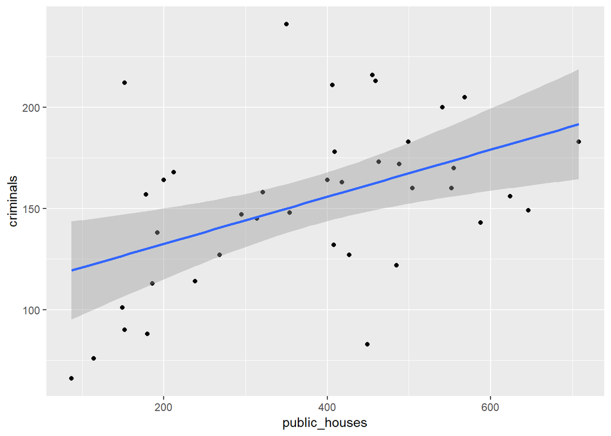

```r
crime %>% ggplot(aes(x=public_houses, y=criminals)) + geom_point() + geom_smooth(method='lm')
```

```r
crm_lm <- lm(formula = criminals ~ public_houses, data = crime)

crm_lm %>% get_regression_table()
```

```
## # A tibble: 2 x 7
##   term          estimate std_error statistic p_value lower_ci upper_ci
##   <chr>            <dbl>     <dbl>     <dbl>   <dbl>    <dbl>    <dbl>
## 1 intercept      109.       14.8        7.41   0       79.5    139.
## 2 public_houses    0.116     0.036      3.22   0.003    0.043    0.189
```

## Part 2

Interpret the intercept coefficient and the slope coefficient (see here for an example). How do the regression results match up with the results from your exploratory data analysis above?

The estimate corresponds to the coefficients b0 and b1 such that:
$$b_0 = 109.34$$
and
$$b_1 = 0.116$$

Which, mathamatically, means that in a land of no public houses there would still be a base population of 109.34 (that poor partial person) but with each additional public house that is then constructed and frequented, an additional 0.116 of a criminal is added. Kind of makes you wonder, which body parts are criminal first?

# Observed/fitted values and residuals

## Part 1

What are the observed and fitted values for the Cornwall (ID = 20) and Monmouth regions (ID = 23)? Which region do you think the reverend called “the happiest example of the infrequency of crime”?

```r
#crime %>% distinct(region_code) # no region code 20,23
model_data <- get_regression_points(crm_lm)
happy_data <- model_data %>% filter(ID==20 | ID==23)
happy_data
```

```
## # A tibble: 2 x 5
##      ID criminals public_houses criminals_hat residual
##   <int>     <dbl>         <dbl>         <dbl>    <dbl>
## 1    20        66            87          119.    -53.4
## 2    23       241           350          150.     91.0
```

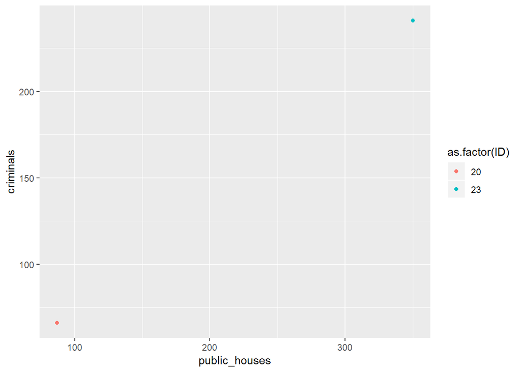

```r
happy_data %>% ggplot(aes(x=public_houses, y=criminals, color=as.factor(ID))) + geom_point()
```

## Part 2

In fact, we could argue with the reverend about the happiest example of the infrequency of crime. There are two ways you could define this, and you’ll do with with a filter using the | operator (think: or).

The first way is that the county had the lowest criminals overall. The second is that the county had the lowest criminals given their number of public houses. This would mean that the region has the lowest observed criminals, compared to the fitted value based on predicting criminals from public houses. You’ll need to match the ID column as a row in the original data (you can just do this visually by comparing the tibbles and typing your answers in your narrative- you don’t have to do a join here).

## My argument

To argue as is expected:

```r
n_crime <- crime %>% mutate(crim_per_houses = criminals / public_houses) %>% select(county, criminals, public_houses, crim_per_houses)

n_crime %>% arrange((criminals)) %>% head()
```

```
## # A tibble: 6 x 4
##   county         criminals public_houses crim_per_houses
##   <chr>              <int>         <int>           <dbl>
## 1 Cornwall              66            87           0.759
## 2 Cumberland            76           114           0.667
## 3 Derby                 83           449           0.185
## 4 Durham                88           180           0.489
## 5 Northumberland        90           152           0.592
## 6 Westmoreland         101           149           0.678
```

```r
n_crime %>% arrange((public_houses)) %>% head()
```

```
## # A tibble: 6 x 4
##   county         criminals public_houses crim_per_houses
##   <chr>              <int>         <int>           <dbl>
## 1 Cornwall              66            87           0.759
## 2 Cumberland            76           114           0.667
## 3 Westmoreland         101           149           0.678
## 4 Hereford             212           152           1.39
## 5 Northumberland        90           152           0.592
## 6 Wilts                157           178           0.882
```

```r
n_crime %>% arrange(desc(crim_per_houses)) %>% head()
```

```
## # A tibble: 6 x 4
##   county   criminals public_houses crim_per_houses
##   <chr>        <int>         <int>           <dbl>
## 1 Hereford       212           152           1.39
## 2 Wilts          157           178           0.882
## 3 Suffolk        164           200           0.82
## 4 Somerset       168           212           0.792
## 5 Cornwall        66            87           0.759
## 6 Devon          138           192           0.719
```

# Residual analysis

## Part 1

Perform a residual analysis and look for any systematic patterns in the residuals. Ideally, there should be little to no pattern- why? Does it seem like there is no systematic pattern to the residuals?

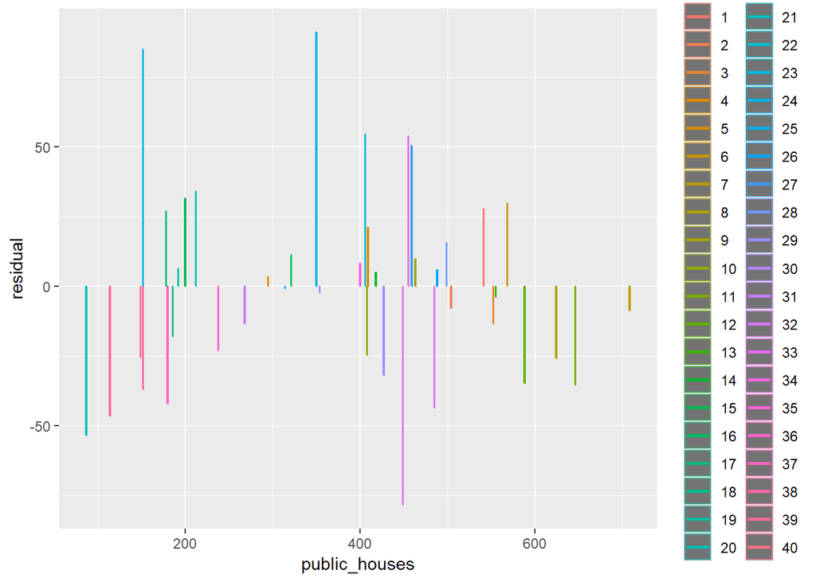

```r
model_data %>% ggplot(aes(x=public_houses, y=residual, color=as.factor(ID))) + geom_col() + geom_smooth(method = 'lm')
```

From this chart, I cannot discern any obvious systemic pattern in the residuals.

## Part 2

Recreate this density plot of the residuals (hint: ?geom_vline()). Recall that we would like the residuals to be normally distributed with mean 0. Use dplyr to calculate the mean of the residuals- is it (pretty close to) 0? Do you think you have more positive residuals than negative, or vice versa?

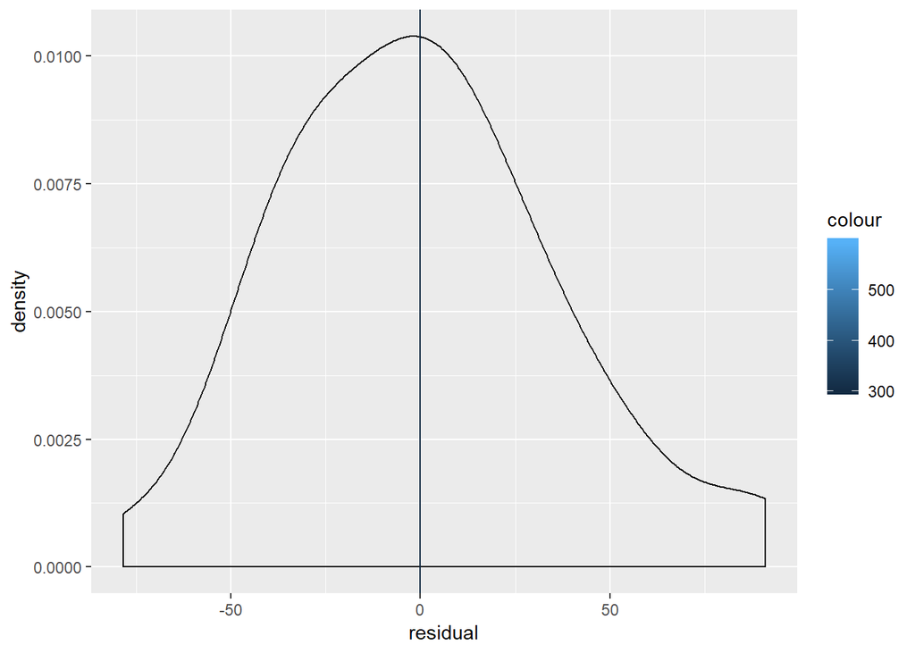

```r
model_data %>% ggplot(aes(x=residual)) + geom_density() + geom_vline(aes(xintercept = mean(model_data$residual), color=594)) + geom_vline(aes(xintercept=0, color = 300))
```

```r
model_data %>% summarize(mean_residue=mean(residual))
```

```
## # A tibble: 1 x 1
##   mean_residue
##          <dbl>
## 1     0.000025
```

From this residual density plot, the heteroskedacity and skew doesn’t seem outrageous and the mean residual is exceedingly close to 0 which is as to be expected. While the model doesn’t have a ton of predictive value, it does seem to apply to all the data fairly well without any systemic biases. Moving forward, I would start to explore other variables that have more predictive value for the criminal variable; education or income would be a good topic to explore next I think.